# Report - Practical Machine Learning Project

# Abstract

# Introduction

Six young health participants were asked to perform one set of 10 repetitions of the Unilateral Dumbbell Biceps Curl in five different fashions: exactly according to the specification (Class A), throwing the elbows to the front (Class B), lifting the dumbbell only halfway (Class C), lowering the dumbbell only halfway (Class D) and throwing the hips to the front (Class E).

Class A corresponds to the specified execution of the exercise, while the other 4 classes correspond to common mistakes. Participants were supervised by an experienced weight lifter to make sure the execution complied to the manner they were supposed to simulate. The exercises were performed by six male participants aged between 20-28 years, with little weight lifting experience. We made sure that all participants could easily simulate the mistakes in a safe and controlled manner by using a relatively light dumbbell (1.25kg).

# Analysis

First, lets get the data clean. Basically we are interested in the raw data of the sensors, so we delete al the sumarization variables, time-related variables and identification variables.

This cleaning procedure comes from two facts and one hipotesis: - Fact 1 - Each sensor is independent: this means that every sensor is not connected to the other and it is positioned in a way that is only capturing information about the downbell or just one of the body parts important for the study. - Fact 2 - Each output category points to specific and independent movements: this means that the movement asociated with one category it is not present in the movement of the others. - Hypothesis: the presence of one movement can be detected with a specific subset of measures in a specific subset of sensors.

In order to validate our hypothesis lets perform some exploratory analysis. Specifically we are going to make some clustering plots. But before start our analysis, lets gets some cross validation data sets: 60% for training, 20% for testing and 20% for validation.

## Belt sensor analysis

Now lets construct some clusters using k-means over the data of the Belt sensor

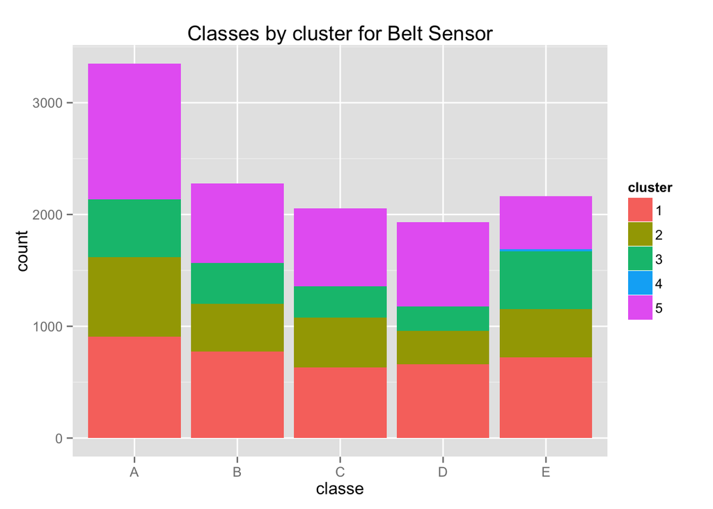

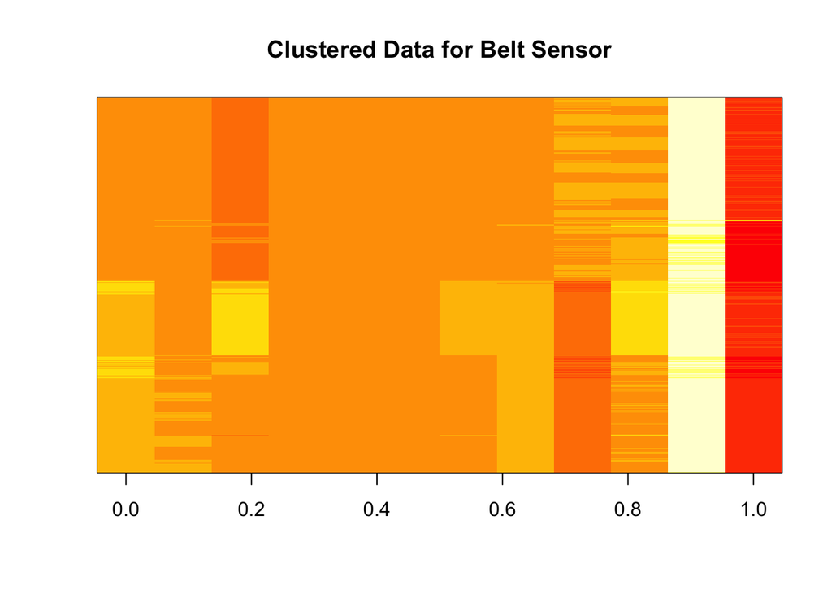

In the above plots we can see a histogram and a heat map of the belt sensor data clustered with 5 centroids using k-means algorithm. In the plots you can see: one cluster that is only associated with the E class, and how well these clusters can be difirentiated in the data (heat map). These facts can be see it as the first evidence that supports our hypothesis: there is a strong signal present in the belt sensor that is very correlated to the class E.

## Dumbbell sensor analysis

Now lets construct some clusters using k-means over the data of the Dumbbell sensor

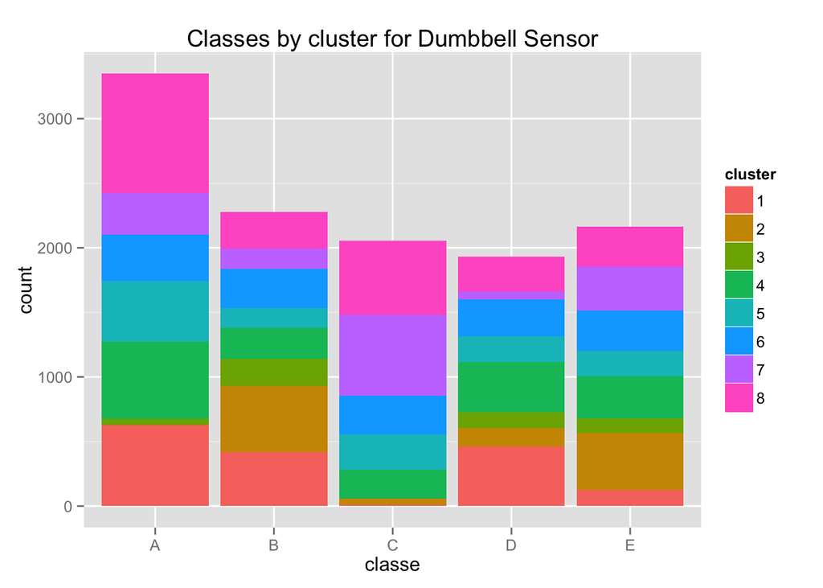

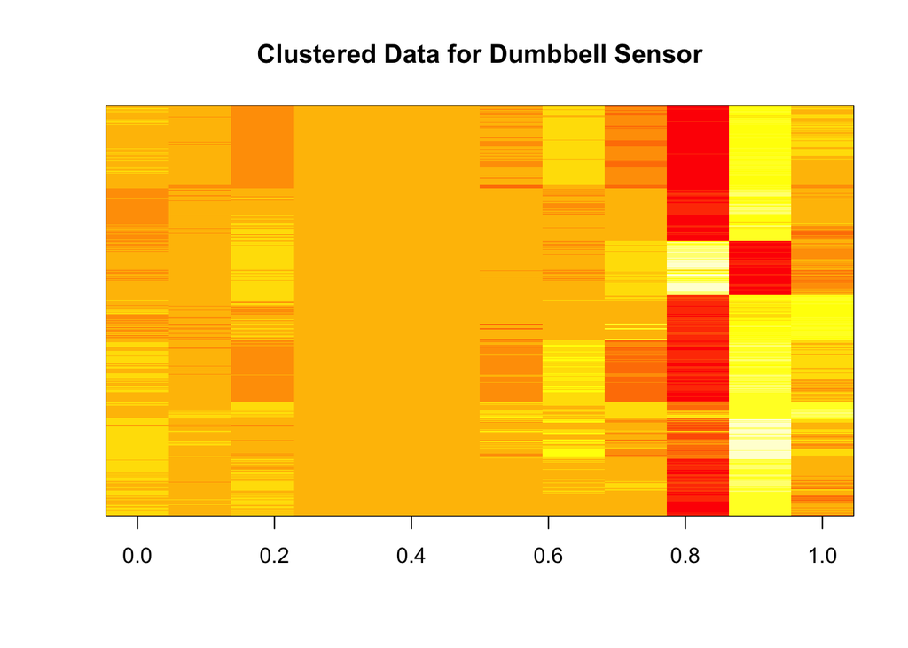

In the above plots we can see a histogram and a heat map of the dumbbell sensor data clustered with 8 centroids using k-means algorithm. In the plots you can see: cluster combinations that are NOT associated with the C and D class, and how well these clusters can be difirentiated in the data (heat map). These facts can be see it as the second evidence that supports our hypothesis: there are strong signals present in the dumbbell sensor that allows clearly difirentiate some classes.

## Arm sensor analysis

Now lets construct some clusters using k-means over the data of the Arm sensor

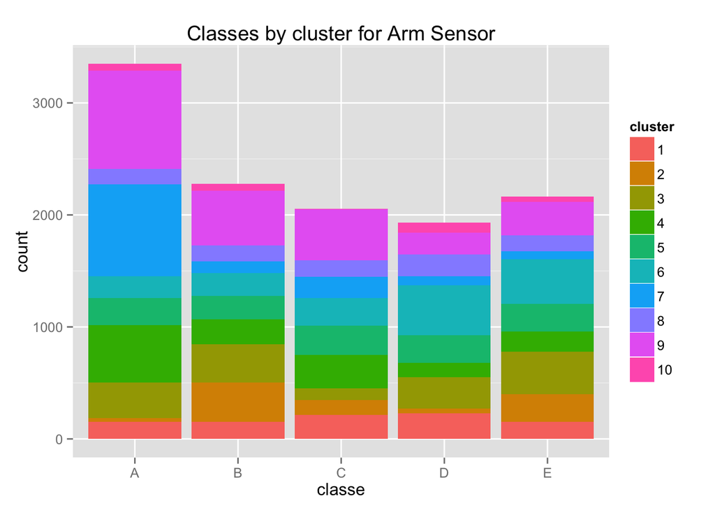

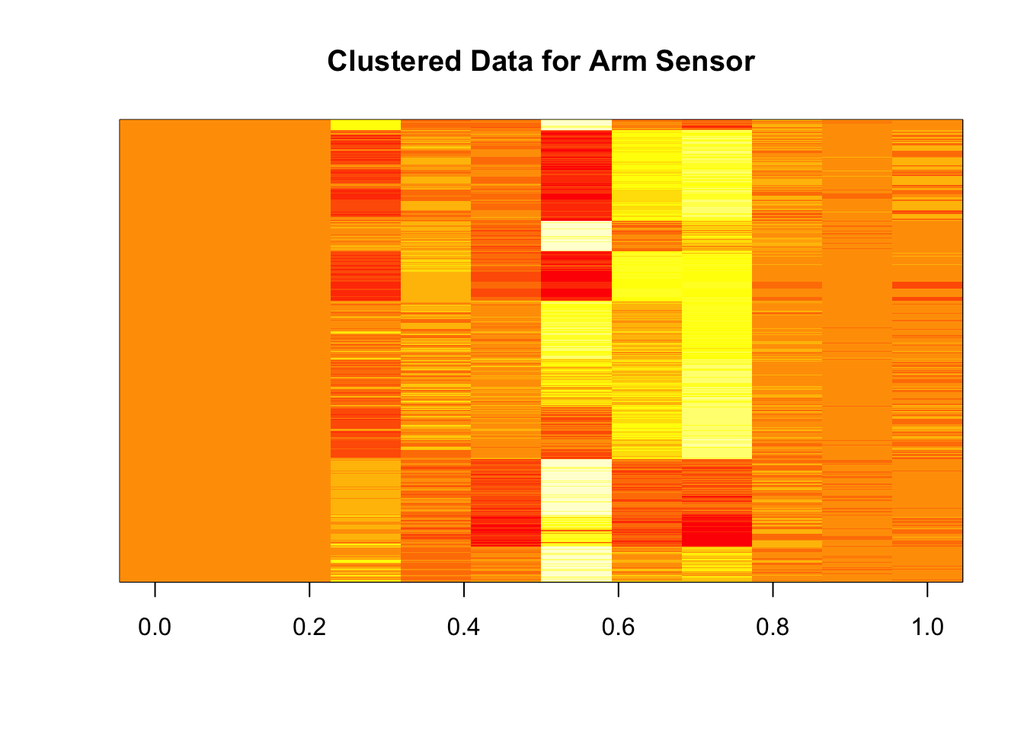

## Forearm sensor analysis

Now lets construct some clusters using k-means over the data of the Forearm sensor

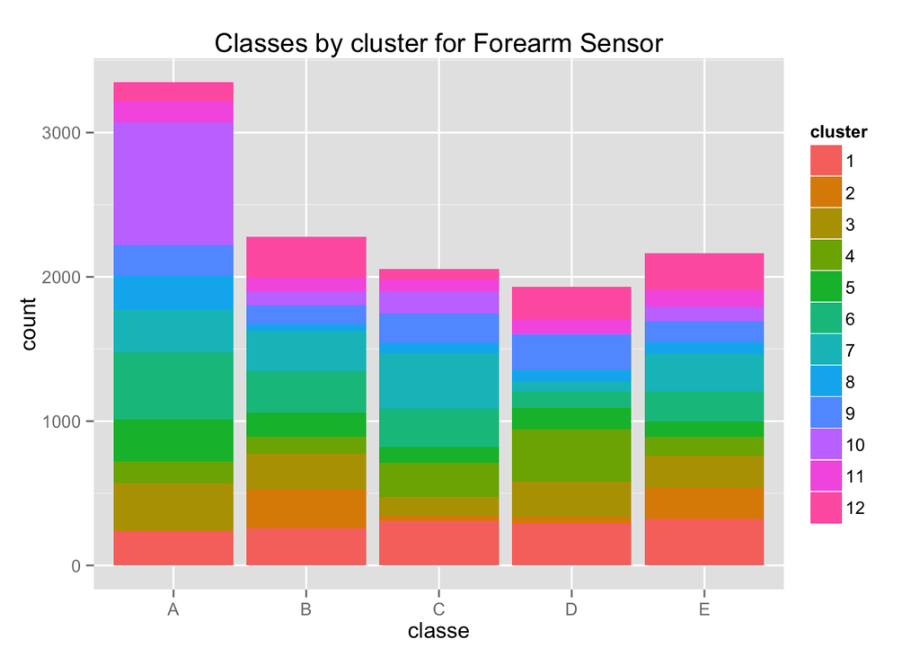

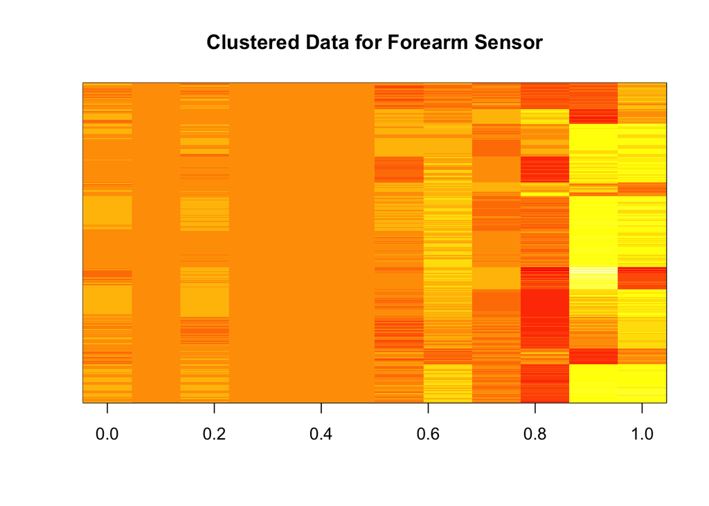

**In order to iterate over the above exploratory analysis, a [Shiny application](https://edilmo.shinyapps.io/PracticalMachineLearningCP) was built.**

# Model

The results of our analysis give support to our hypothesis which indicates that discriminative algorithm as random forrest could be a go approach to our prediction problem. The only problem is the amount of variables. There to many variables and for these kind of cases the performance of random forrest could be a problem. Our approach to the dimensionality problem is use PCA separately for each group of variables associated to the same sensor. We are omitting the mathematical details but the PCA components of the entire data set are not the same that the composition of the PCA components of the group of variables asociated to each sensor. This procedure allows to “isolate” the data of each sensor a little bit and increase the “independence”" between them.

Lets reduce the dimensionality of our data set using PCA.

- The variables measured by the Belt Sensor are 12. And the number of Principal Components are 3.
- The variables measured by the Forearm Sensor are 12. And the number of Principal Components are 6.
- The variables measured by the Dumbbell Sensor are 12. And the number of Principal Components are 5.
- The variables measured by the Arm Sensor are 12. And the number of Principal Components are 5.

Now, let’s use our new components to generate new training data using that dimensions:

Let’s fit a model using “rf”:

Now let’s test our model with the cross validation data:

Different iterations were performed using the test data but here we are just presenting the results of the final iteration:

|  | Sensitivity | Specificity | Pos Pred Value | Neg Pred Value | Prevalence | Detection Rate | Detection Prevalence | Balanced Accuracy |
| --- | --- | --- | --- | --- | --- | --- | --- | --- |
| Class: A | 0.9736611 | 0.9974856 | 0.9937276 | 0.9893124 | 0.2903390 | 0.2826918 | 0.2844762 | 0.9855734 |
| Class: B | 0.9797844 | 0.9899403 | 0.9578393 | 0.9952592 | 0.1891410 | 0.1853174 | 0.1934744 | 0.9848623 |
| Class: C | 0.9528571 | 0.9947254 | 0.9751462 | 0.9898117 | 0.1784349 | 0.1700229 | 0.1743564 | 0.9737913 |
| Class: D | 0.9838710 | 0.9900091 | 0.9486781 | 0.9969512 | 0.1580423 | 0.1554932 | 0.1639052 | 0.9869400 |
| Class: E | 0.9930748 | 0.9987504 | 0.9944521 | 0.9984385 | 0.1840428 | 0.1827683 | 0.1837879 | 0.9959126 |

# Results

```
##       Accuracy          Kappa  AccuracyLower  AccuracyUpper   AccuracyNull
##      0.9762937      0.9699909      0.9710359      0.9808243      0.2903390
## AccuracyPValue  McnemarPValue
##      0.0000000            NaN
```